# Visualize Data With ggplot2

Taotao

10/25/2020

## Data Visualization basic

### Boxplot

ggplot use “+” to add new elements, which makes it very flexible.

boxplot is particularly good to visualize the relationship between a numeric and categorical data. e.g. Plant species vs Petal.Length

For more information, check this [post](http://www.sthda.com/english/wiki/ggplot2-box-plot-quick-start-guide-r-software-and-data-visualization)

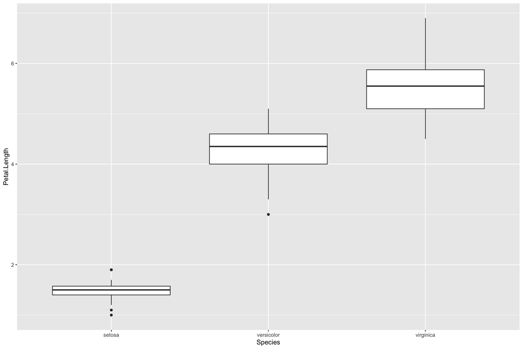

```r
library(ggplot2)


# basic boxplot with ggplot2
ggplot(iris) + aes(x = Species, y = Petal.Length) + geom_boxplot()
```

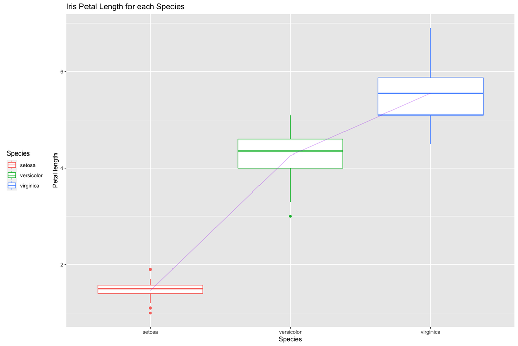

```r
# initiate the plot
ggplot(iris) + aes(x = Species, y = Petal.Length, color = Species) +
      # add a layer boxplot
      geom_boxplot() +
      # modify the legend position, default is right
      theme(legend.position="left") +
      # add x and y lables and title
      labs(title="Iris Petal Length for each Species",x="Species", y = "Petal length") +
      # add a summary line that connect all the mean between groups
      stat_summary(fun=mean, geom="line", aes(group = 1), col = "purple", alpha = 0.3)
```

#### An alternative for boxplot: violin plot

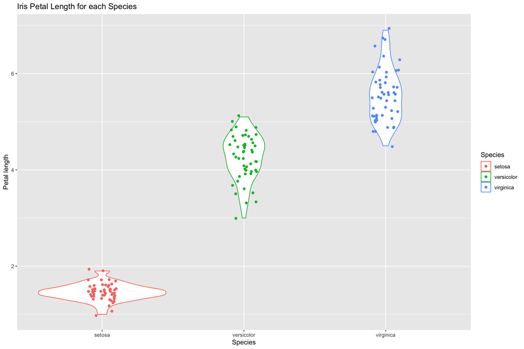

```r
ggplot(iris) + aes(x = Species, y = Petal.Length, color = Species) +
    geom_violin() +
    # add each single dots
    geom_jitter(position=position_jitter(0.1))+
    # change the title and labels
    labs(title="Iris Petal Length for each Species",x="Species", y = "Petal length")
```

Which one is better? Boxplot or Violin plot?

### Scatter plot

Scatter plot is often used for visualizing two numberic vectors

For more information, check this [post](http://www.sthda.com/english/wiki/ggplot2-scatter-plots-quick-start-guide-r-software-and-data-visualization)

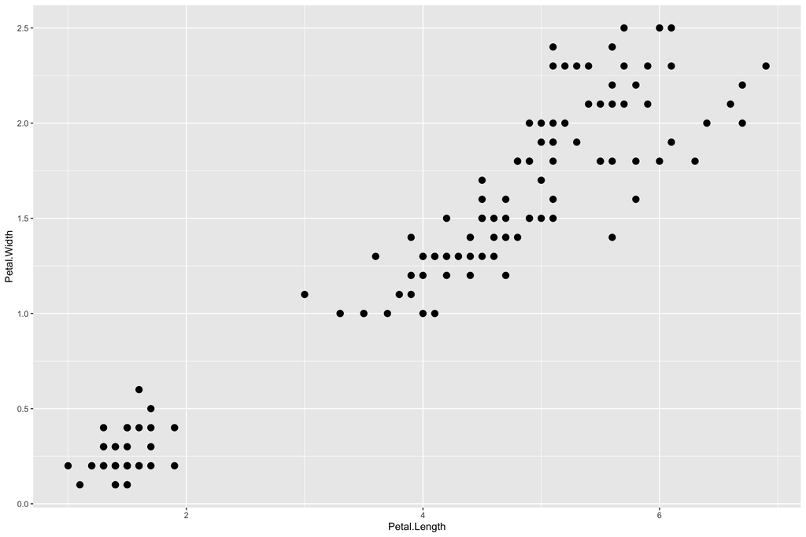

```r
# A basic scatter plot with ggplot2
ggplot(iris) + aes(x = Petal.Length, y = Petal.Width) + geom_point(size = 3)
```

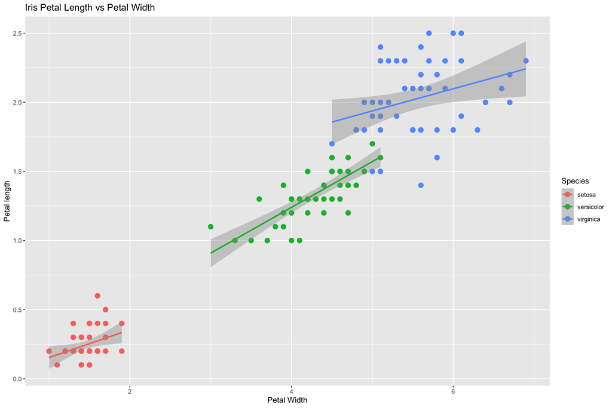

```r
# in aes, indicate color = Species, so that ggplot2 can set a distinct color to each species
ggplot(iris) + aes(x = Petal.Length, y = Petal.Width, col = Species) +
    # add point
    geom_point(size = 3) +
    # geom_smooth can fit each group with a linear model, and draw confidence interval.
    geom_smooth(method = lm) +
    # it's possible to fit a grand linear model to all the data; in order to do so, simply use a different color in geom_smooth
    # geom_smooth(method = lm, color = "purple")
    labs(title="Iris Petal Length vs Petal Width",x="Petal Width", y = "Petal length")
```

#### How to combine multiple plots

For more information, check this [post](http://www.sthda.com/english/wiki/wiki.php?id_contents=7930#add-a-common-legend-for-multiple-ggplot2-graphs)

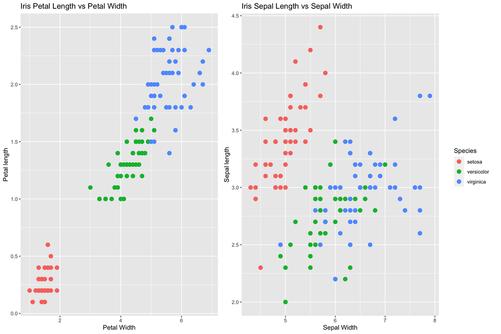

```r
library(ggpubr)
library(gridExtra)

# the first plot
p1 <- ggplot(iris) + aes(x = Petal.Length, y = Petal.Width, col = Species) +
    geom_point(size = 3) +
    labs(title="Iris Petal Length vs Petal Width",x="Petal Width", y = "Petal length")


# the second plot
p2 <- ggplot(iris) + aes(x = Sepal.Length, y = Sepal.Width, col = Species) +
    geom_point(size = 3) +
    theme(legend.position="none") +
    labs(title="Iris Sepal Length vs Sepal Width",x="Sepal Width", y = "Sepal length")

# extract legend from p1, then reset the legend = null for p1
legend <- get_legend(p1)
p1 <- p1 + theme(legend.position="none")

# use gridExtra::grid.arrange to make subplot, remember to set width for each subplot(p1, p2, legend)
grid.arrange(p1, p2, legend, nrow = 1, widths=c(3, 3, 0.8))
```

## Barplot

Barplot gives us very limited amount of information, normally we would rather use boxplot. Why?

For more information, check this [post](http://www.sthda.com/english/wiki/ggplot2-barplots-quick-start-guide-r-software-and-data-visualization)

```r
# calculate mean for each species
setosa_mean =  mean(iris[iris$Species == "setosa", "Sepal.Length"])
versicolor_mean =  mean(iris[iris$Species == "versicolor", "Sepal.Length"])
virginica_mean =  mean(iris[iris$Species == "virginica", "Sepal.Length"])

# write into a dataframe
Sepal_Length_mean <- c(setosa_mean, versicolor_mean, virginica_mean)
names(Sepal_Length_mean) <- c("setosa", "versicolor", "virginica")
bar_df <- as.data.frame(Sepal_Length_mean)
bar_df$Species <- row.names(bar_df)
bar_df
```

```
##            Sepal_Length_mean    Species
## setosa                 5.006     setosa
## versicolor             5.936 versicolor
## virginica              6.588  virginica
```

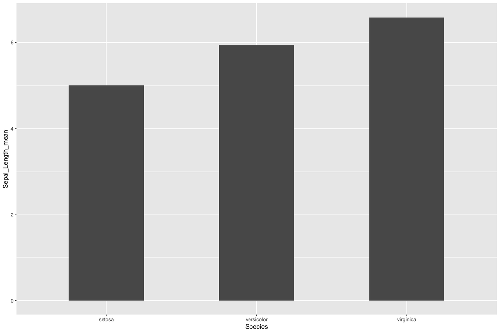

```r
# barplot
ggplot(bar_df) + aes(x = Species, y = Sepal_Length_mean ) +
    geom_bar(stat="identity", width=0.5)
```

Compare boxplot and barplot, which is better.

## Histogram

Histogram is used to visualize a numeric vector

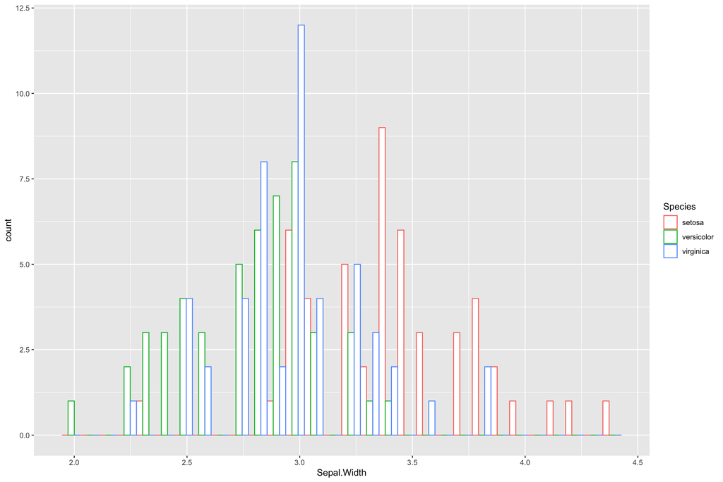

```r
ggplot(iris) +
    aes(x=Sepal.Width, color=Species) +
    geom_histogram(fill = "white",position="dodge", bins = 30)
```

Technically you can use histogram to visualize multi-dimensional data (color), but this is not a good practice in general, why?

## Data Visualization for RNA-seq.

It’s much more challenging to visualize RNA-seq data? Why?

Let’s read the count and design file first. This is the dataset we used in the last class.

```r
library(DESeq2)

# read the count matrix and design matrix
counts = read.csv("count.csv", row.names = 1)
design = read.csv("design.csv", row.names = 1)

# differential expression
dds = DESeqDataSetFromMatrix(countData = counts, colData = design, design = ~ condition)
dds = DESeq(dds)
res <- results(dds)
head(res)
```

```
## log2 fold change (MLE): condition NO3 vs KCL
## Wald test p-value: condition NO3 vs KCL
## DataFrame with 6 rows and 6 columns
##            baseMean log2FoldChange     lfcSE       stat    pvalue      padj
##           <numeric>      <numeric> <numeric>  <numeric> <numeric> <numeric>
## AT1G01010 31.350151     -0.6214701  0.538229 -1.1546571  0.248231  0.999768
## AT1G01020  4.735895     -0.2604466  1.222285 -0.2130817  0.831263        NA
## AT1G01030  1.163981     -0.0776611  2.484382 -0.0312597  0.975062        NA
## AT1G01040 59.544781      0.3858091  0.400219  0.9639954  0.335048  0.999768
## AT1G01046  0.216506     -0.8868834  4.981302 -0.1780425  0.858690        NA
## AT1G01050 30.182041      0.6409997  0.521474  1.2292067  0.218994  0.999768
```

### Build-in function of DESeq2

#### MA plot

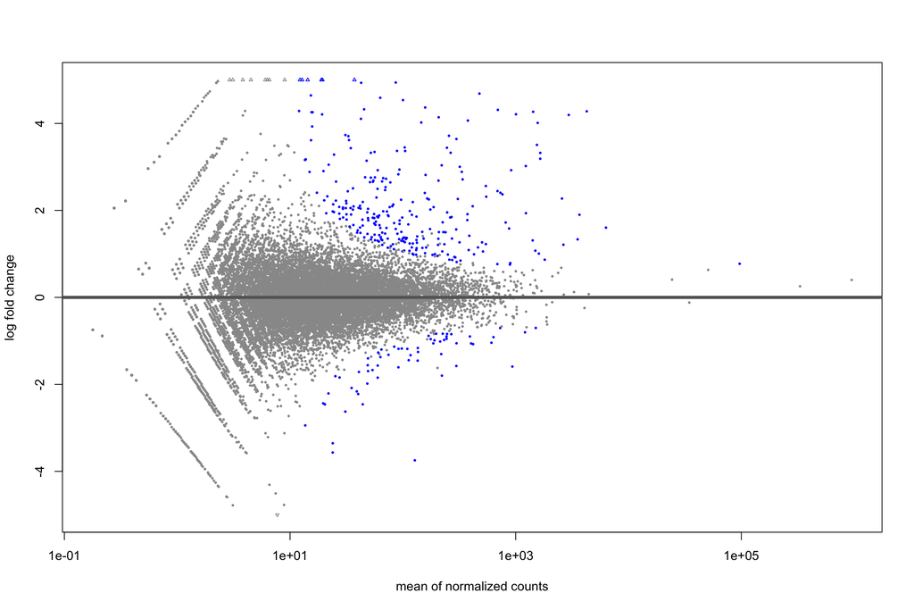

```r
plotMA(res, ylim=c(-5,5))
```

#### PCA

Before plotting, we need to do two things:

1. perform variance stabilization transformation
2. calculate the PCA

DESeq2::plotPCA automatically perform the second step for us

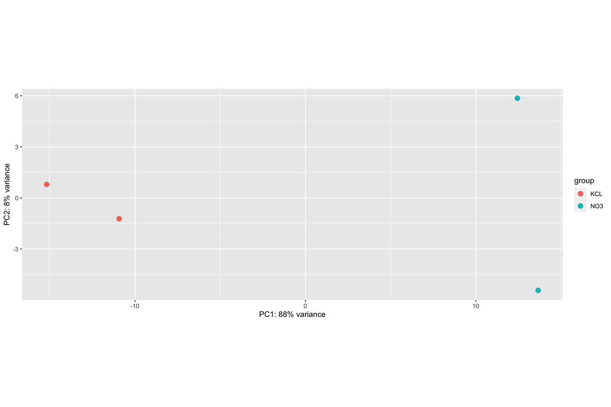

```r
# vsd transformation
vsd <- vst(dds, blind=FALSE)

# plot PCA
plotPCA(vsd, intgroup=c("condition"))
```

PCA is a very general technique for plotting. For any multi-dimentional dataframe, we can use the following code to visualize the data.

Compute the principal components, and choose two PCs (usually PC1 vs PC2). PC1 explains the most variation of the data, PC2 explains less variation than PC1, PC3 less than PC2…

```r
library(factoextra)
# retrieve the vsd transformed data
vsd_data <- t(vsd@assays@data@listData[[1]])


# calculate the PCA
pca_res = prcomp(vsd_data, scale = F)
# retrieve the new PC coordinate
pca_res$x
```

```
##                               PC1        PC2        PC3           PC4
## KCL_1.fastq.subread.BAM -22.52335   3.405000  13.032643  1.643642e-13
## KCL_2.fastq.subread.BAM -16.05273  -4.893487 -15.284629  3.438610e-13
## NO3_1.fastq.subread.BAM  18.51353  20.480531  -1.935557 -4.767733e-13
## NO3_2.fastq.subread.BAM  20.06255 -18.992045   4.187544  8.419535e-15
```

```r
# save PC coordinates into a dataframe for the sake of plotting
pc_data = as.data.frame(pca_res$x)
pc_data$group = as.factor(c("KCL","KCL", "NO3", "NO3"))
pc_data
```

```
##                               PC1        PC2        PC3           PC4 group
## KCL_1.fastq.subread.BAM -22.52335   3.405000  13.032643  1.643642e-13   KCL
## KCL_2.fastq.subread.BAM -16.05273  -4.893487 -15.284629  3.438610e-13   KCL
## NO3_1.fastq.subread.BAM  18.51353  20.480531  -1.935557 -4.767733e-13   NO3
## NO3_2.fastq.subread.BAM  20.06255 -18.992045   4.187544  8.419535e-15   NO3
```

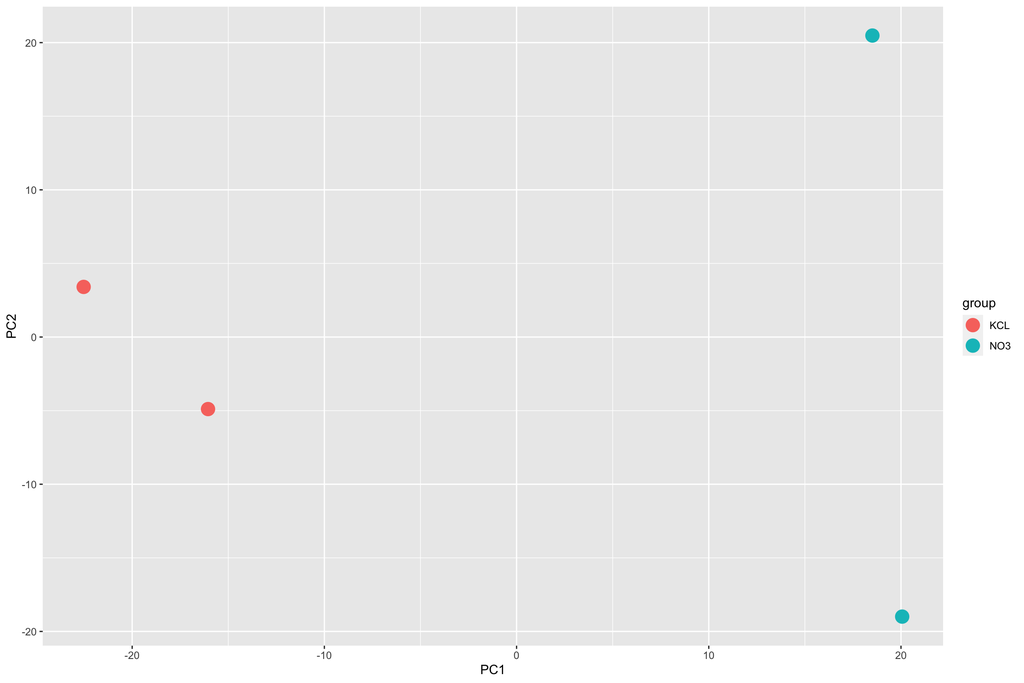

```r
# scatter plot for PC1 and PC2
ggplot(pc_data) + aes(x = PC1, y = PC2, color = group) + geom_point(size= 5)
```

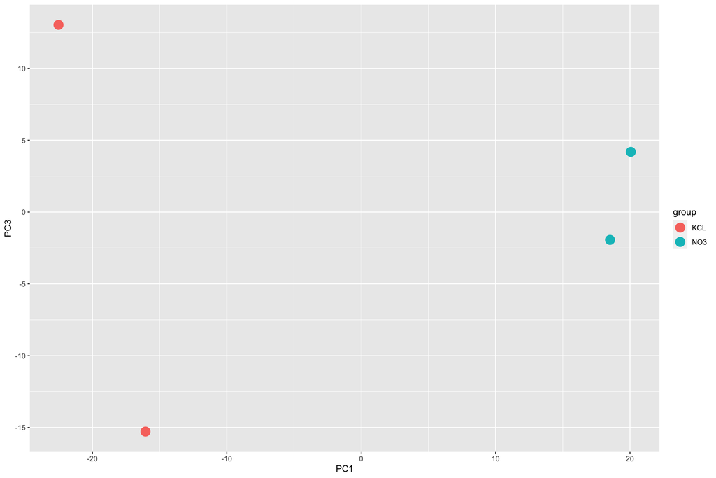

```r
# scatter plot for PC1 and PC3
ggplot(pc_data) + aes(x = PC1, y = PC3, color = group) + geom_point(size= 5)
```

### heatmap

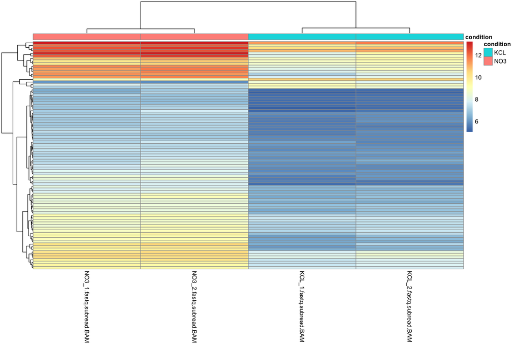

```r
library(pheatmap)

# assay(vsd)[which(res$padj < 0.00001),] retrieve the differentially expressed gene.
selected_genes = assay(vsd)[which(res$padj < 0.00001),]

# use the design matrix to annotate columns
row.names(design) <- colnames(counts)

# pheatmap, cluster both row and columns
pheatmap(selected_genes, cluster_rows=TRUE, show_rownames=FALSE,
         cluster_cols=TRUE, annotation_col = design)
```

You should adjust the number of genes to include in the heatmap. Thousands of genes may not be feasible. You can also label the gene name if the size of selected genes is small.

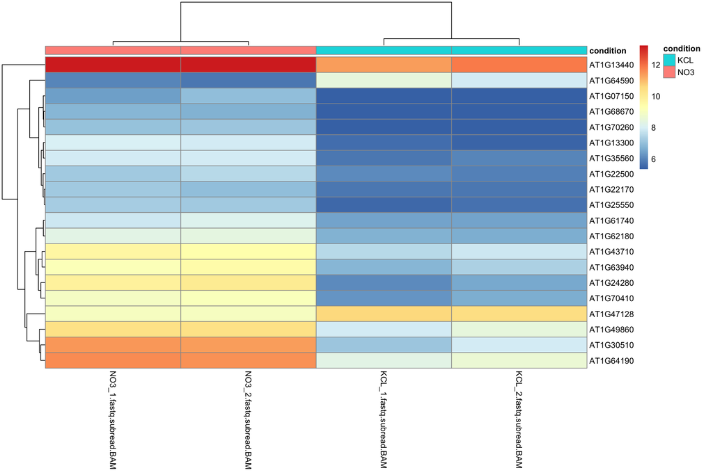

```r
pheatmap(selected_genes[1:20,], cluster_rows=TRUE, show_rownames=TRUE, show_colnames = TRUE,
         cluster_cols=TRUE, annotation_col = design)
```